# Perform GSEA

Stephanie J. Spielman

2025-03-11

The purpose of this notebook is to run GSEA on the median of linear model residuals. Genes that are enriched in higher or lower residual values may point to classes genes that are preferentially detected by bulk vs single-cell RNASeq technologies.

In addition, we will also run the same GSEA on shuffled gene sets (with 50) to assess whether any results from GSEA are likely to be meaningful or noise.

- This notebook will use the H gene sets from `MSigDB` for the GSEA.
- This notebook will perform analyses on models from data filtered with this expression threshold: 0.25.

## Setup

```r
renv::load()

library(ggplot2)
library(clusterProfiler)
theme_set(theme_bw())
set.seed(2025)
```

### Paths

```r
model_dir <- here::here("analysis", "pseudobulk-bulk-prediction", "results", "models")
ensembl_symbol_df <- readr::read_tsv(
  here::here("analysis", "bulk-deconvolution", "data", "reference", "ensembl_symbol.tsv"),
  show_col_types = FALSE
)
```

### Functions

This chunk defines a function to create a list of data frames with given number of replicates of shuffled versions of the `geneset_df`.

```r
generate_shuffled_genesets <- function(geneset_df, reps){

  geneset_count_df <- geneset_df |>
    dplyr::count(gs_name)

  unique_ensembl_ids <- geneset_df |>
    dplyr::distinct(human_ensembl_gene) |>
    dplyr::pull(human_ensembl_gene)

  shuffled_df_list <- 1:reps |>
    purrr::map(
      \(i) {
        shuffled_df <- geneset_count_df |>
          purrr::pmap(
          \(gs_name, n) {
          data.frame(
            gs_name = gs_name,
            ensembl_id = sample(unique_ensembl_ids, n) # no replacement!
          )
        }) |>
        purrr::list_rbind()

        stopifnot("Failed to shuffle genes" = nrow(shuffled_df) == nrow(geneset_df))

        return(shuffled_df)
    })

  return(shuffled_df_list)
}
```

## Read and prepare data

```r
# get file name strings based on model_expr_threshold
ext_str <- ifelse(params$model_expr_threshold < 0, "all-genes", glue::glue("threshold-{params$model_expr_threshold}"))
```

```r
data_files <- list.files(
  path = model_dir,
  full.names = TRUE,
  pattern = paste0(ext_str, "\\.tsv$")
) |>
  purrr::set_names(
    \(f) stringr::str_split_i(basename(f), pattern = "_", i = 1)
  )

n_projects <- 5
stopifnot(
  "Data files not found. Check the provided model file extension." = length(data_files) == n_projects
)

ranked_residuals_list <- data_files |>
  purrr::map(
  \(f) {
    readr::read_tsv(f) |>
      # get a ranked list
      dplyr::group_by(ensembl_id) |>
      dplyr::summarize(median_res = median(residual)) |>
      dplyr::arrange(-median_res) |>
      dplyr::pull(median_res, name = ensembl_id)
  }
)
```

## Define the gene signatures of interest

```r
num_genesets <- msigdbr::msigdbr_collections() |>
  dplyr::filter(gs_cat == params$msigdbr_category) |>
  dplyr::pull(num_genesets)

geneset_df <- msigdbr::msigdbr(species = "Homo sapiens", category = params$msigdbr_category)
```

The H signature set contains 50 gene sets.

## Perform GSEA

Next, we’ll run GSEA on this data.

```r
gsea_df <- ranked_residuals_list |>
  purrr::map(
  \(ranked_genes) {

    gsea_result <- clusterProfiler::GSEA(
      geneList = ranked_genes,
      TERM2GENE = dplyr::select(geneset_df, gs_name, human_ensembl_gene)
    )
    gsea_result@result |>
      dplyr::summarize(
        bulk_enriched = sum(NES > 0),
        pseudobulk_enriched = sum(NES < 0)
      )
  }) |> purrr::list_rbind(names_to = "project_id") |>
  # format data for plotting
  tidyr::pivot_longer(
    contains("enriched"),
    names_to = "direction",
    values_to = "count"
  ) |>
  dplyr::mutate(
    # pseudobulk should be first
    direction = forcats::fct_rev(direction),
    # calculate fraction version
    frac = round(count/num_genesets, 2)
  )
```

[output not shown]

[output not shown]

[output not shown]

[output not shown]

[output not shown]

[output not shown]

[output not shown]

[output not shown]

[output not shown]

[output not shown]

[output not shown]

[output not shown]

[output not shown]

[output not shown]

[output not shown]

[output not shown]

[output not shown]

[output not shown]

[output not shown]

[output not shown]

[output not shown]

[output not shown]

[output not shown]

[output not shown]

[output not shown]

## Perform GSEA with shuffled gene sets

We’ll first create 50 shuffled versions of the gene sets.

```r
shuffled_geneset_list <- generate_shuffled_genesets(geneset_df, params$reps)
```

Now, we can run GSEA on all shuffled gene set versions:

(This next chunk takes a little bit to run; we’ll turn off messages and warnings since this is quite a lot of GSEAs!)

```r
shuffled_gsea_df <- ranked_residuals_list |>
  purrr::map(
  \(ranked_genes) {

    purrr::map(
      shuffled_geneset_list,
      \(shuffled_rep) {
        gsea_result <- clusterProfiler::GSEA(
          geneList = ranked_genes,
          TERM2GENE = shuffled_rep
        )
        gsea_result@result |>
          dplyr::summarize(
            bulk_enriched = sum(NES > 0),
            pseudobulk_enriched = sum(NES < 0)
          )
      }
    ) |> purrr::list_rbind(names_to = "rep")

  }) |>
  purrr::list_rbind(names_to = "project_id") |>
  # format data for plotting
  tidyr::pivot_longer(
    contains("enriched"),
    names_to = "direction",
    values_to = "count"
  ) |>
  dplyr::mutate(
    # pseudobulk should be first
    direction = forcats::fct_rev(direction),
    # calculate fraction version
    frac = count/num_genesets
  )
```

## Compare GSEA to shuffled GSEA results

Finally, we’ll make plots comparing these two analyses:

- A bar plot of the proportion of input pathways returned as significant per project detected with GSEA
- A histogram of the proportion of input random gene sets returned as significant per project detected across the 50 replicates of GSEA

Note that these plots considers all results GSEA deemed to be significant; there is no further filtering by effect size or P-value at this time.

Again, for context, the H signature category analyzed here contains 50 total gene sets.

#### GSEA results

Each pair of bars in this plot represents a single GSEA result. The fraction represents the number of gene sets identified as significant.

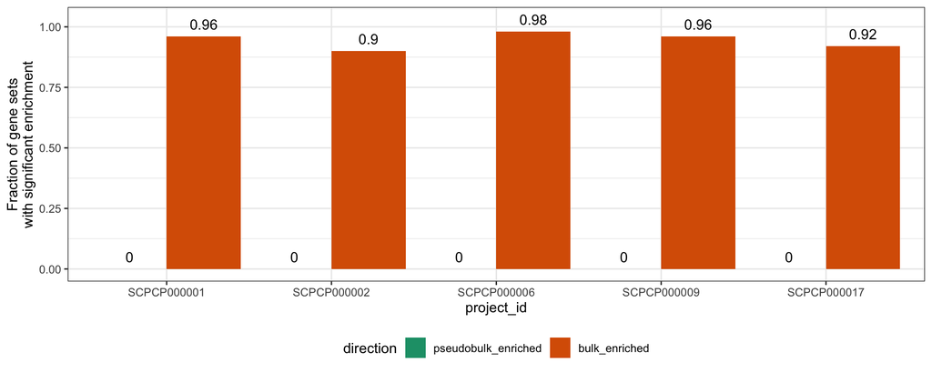

```r
ggplot(gsea_df) +
  aes(x = project_id, y = frac, fill = direction) +
  geom_col(position = position_dodge(width = 0.9)) +
  geom_text(
    aes(label = frac, y = frac + 0.05),
    position = position_dodge(width = 0.9)
  ) +
  scale_fill_brewer(palette = "Dark2") +
  ylab("Fraction of gene sets\nwith significant enrichment") +
  theme(legend.position = "bottom")
```

#### Shuffled GSEA results

This histogram depicts results from 50 GSEAs on run on shuffled gene sets. There are therefore 50 values in the plot for each enrichment direction. This is technically an “overlaid” histogram of two categories, but the two categories tend to have low variation and lie at different ends of the axes.

Each bar can be interpreted as: `X*100`% of the gene sets were enriched in the given direction across `Y` replicates.

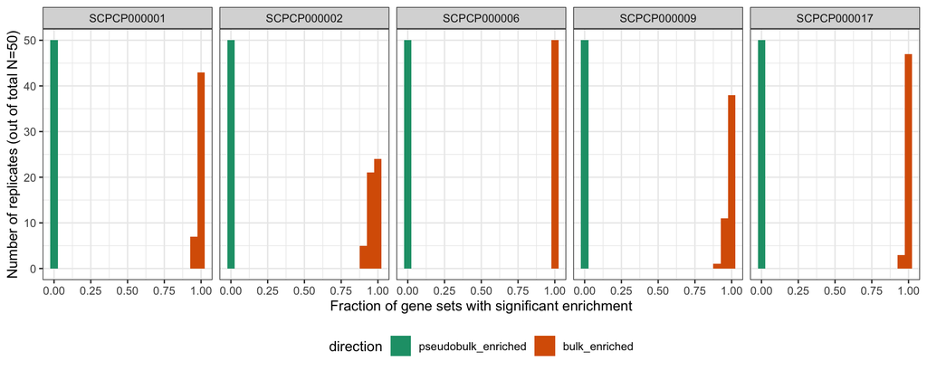

```r
ggplot(shuffled_gsea_df) +
  aes(x = frac, fill = direction) +
  geom_histogram(binwidth = 0.05) +
  facet_wrap(vars(project_id), nrow = 1) +
  scale_fill_brewer(palette = "Dark2") +
  labs(
    x = "Fraction of gene sets with significant enrichment",
    y = glue::glue("Number of replicates (out of total N={params$reps})")
  ) +
  theme(legend.position = "bottom")
```